# Exploratory Data Analysis

Noah Moyer

2023-03-06

### Packages and reading in data

```r
library(here)
library(readxl)
library(dplyr)
```

```r
library(ggplot2)
library(corrr)
library(corrplot)
library(writexl)
```

Now I will read in the overall data but also the raceProfile and riderProfile data. I am reading in both raceProfile and riderProfile because these will be easier to conduct exploratory data analysis on.

```r
#read in bikingDF
biking <- read_excel(here("Project", "rawData", "bikingDF.xlsx"))

#read in raceProfile
raceProfile <- read_excel(here("Project", "rawData", "raceProfile.xlsx"))

#read in riderProfile
riderProfile <- read_excel(here("Project", "rawData", "RiderProfile.xlsx"))
```

### Exploring the biking dataframe

First I am going to explore the main biking dataframe.

```r
#general exploration
str(biking)
```

```
## tibble [20,305 × 37] (S3: tbl_df/tbl/data.frame)
##  $ raceName              : chr [1:20305] "AmstelGold" "AmstelGold" "AmstelGold" "AmstelGold" ...
##  $ RiderName             : chr [1:20305] "VAN AVERMAET GregAG2R Citroën Team" "BETTIOL AlbertoEF Education-EasyPost" "APERS RubenSport Vlaanderen - Baloise" "HAIG JackBahrain - Victorious" ...
##  $ RiderLastName         : chr [1:20305] "Van Avermaet" "Bettiol" "Apers" "Haig" ...
##  $ Team                  : chr [1:20305] "AG2R Citroën Team" "EF Education-EasyPost" "Sport Vlaanderen - Baloise" "Bahrain - Victorious" ...
##  $ AgeYear               : num [1:20305] 37 29 24 29 23 25 35 29 25 26 ...
##  $ WeightKG              : num [1:20305] 74 69 70 67 75 67 77 70 66 73 ...
##  $ HeightM               : num [1:20305] 1.81 1.8 1.79 1.9 1.84 1.8 1.85 1.8 1.8 1.93 ...
##  $ OneDayRaceScore       : num [1:20305] 11470 1825 88 605 239 ...
##  $ GCScore               : num [1:20305] 3717 621 1 2287 171 ...
##  $ TimeTrialScore        : num [1:20305] 575 662 16 268 230 1 3 4 3 214 ...
##  $ SprintScore           : num [1:20305] 4951 221 50 178 137 ...
##  $ ClimberScore          : num [1:20305] 7664 1748 11 2250 706 ...
##  $ PCSRanking            : num [1:20305] 80 70 664 163 91 ...
##  $ Wins                  : num [1:20305] 41 4 0 2 0 0 0 1 0 3 ...
```

[output cut: 23 more lines]

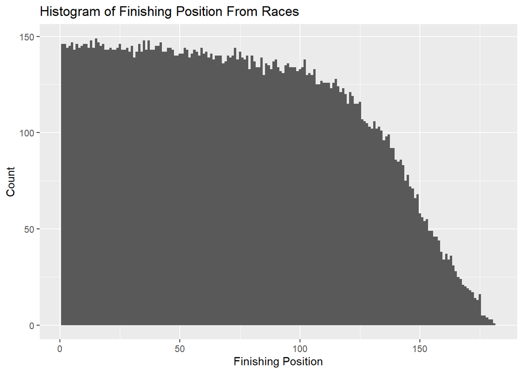

```r
#barplot
ggplot(data=biking, aes(x=Rnk)) +
  geom_histogram(binwidth=1) +
  labs(title="Histogram of Finishing Position From Races", x="Finishing Position", y="Count")
```

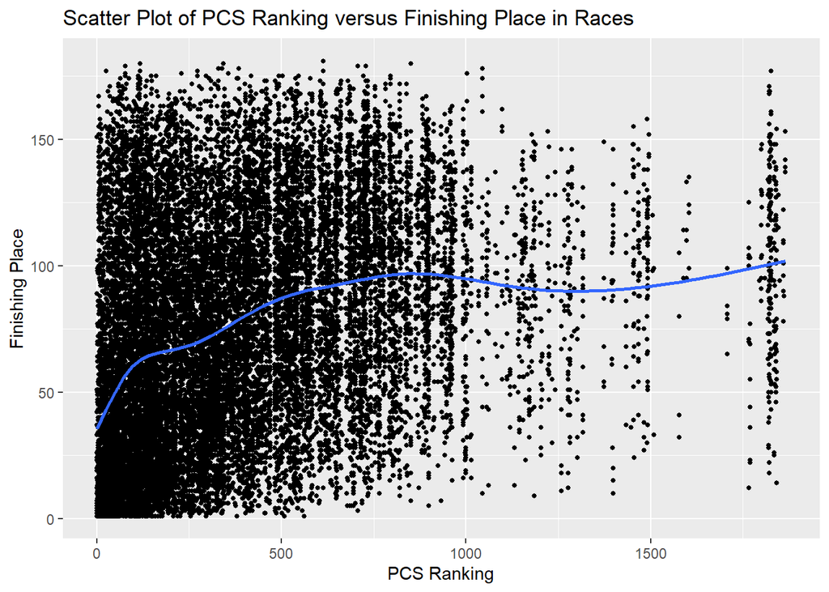

```r
#Finishing place versus PCS ranking
ggplot(biking, aes(x=PCSRanking, y=Rnk)) +
  geom_point(size=1) +
  geom_smooth(se=FALSE) +
  labs(title="Scatter Plot of PCS Ranking versus Finishing Place in Races", x="PCS Ranking", y="Finishing Place")
```

There is something curious to note about the finishing position. I would expect the bar chart to have a smooth trend to it (ie the number of finishers in position n never exceeds the number of finishers in position n-1) but this does not appear to be the case. This may have occurred due to removing NAs or may be a data entry error. I will continue to keep an eye out for this in my coming analysis. I also produced a scatter plot of PCS ranking versus finishing place. This graph shows what we would expect. As a rider has a lower PCS Ranking, lower finishing places are achieved. It is definitely worth noting, however, that the slope of the spline varies throughout the graph. It is very steep from a PCS ranking of one through about 150. Thus, the high ranked riders win a lot more than even riders ranked slightly lower. After that, the spline smooths out, showing that PCS ranking matters less here.

Now, I want to produce some graph about riders who finished in the top 10

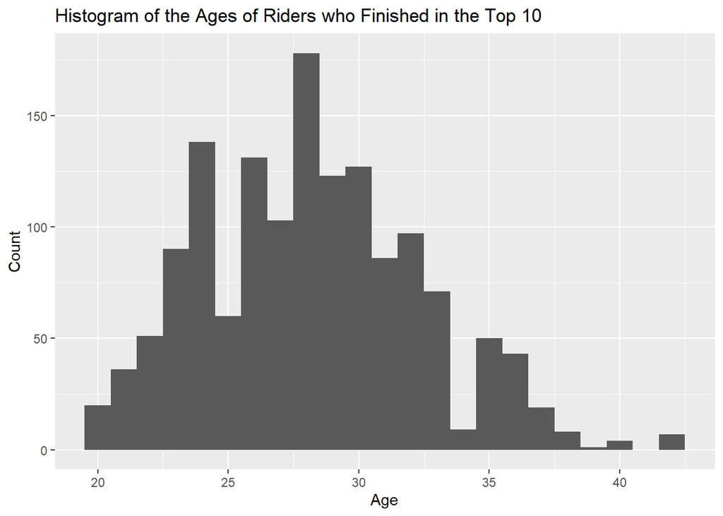

```r
#first, I am going to create a subset of data where we only include riders who finished in the top 10 of a race
bikingTop10 <- biking %>%
  filter(Rnk<=10)

#now lets make a histogram of these rider's ages
ggplot(bikingTop10, aes(x=AgeYear)) +
  geom_histogram(binwidth=1) +
  labs(title="Histogram of the Ages of Riders who Finished in the Top 10", x="Age", y="Count")
```

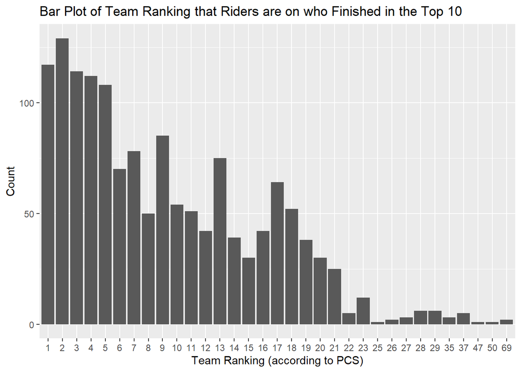

```r
#a histogram of teams of these riders
ggplot(bikingTop10, aes(x=factor(PCSTeamRanking))) +
  geom_bar(stat="count") +
  labs(title="Bar Plot of Team Ranking that Riders are on who Finished in the Top 10", x="Team Ranking (according to PCS)", y="Count")
```

The first graph, we can tell that age is approximately normally distributed around 28. It is interesting to note that there are not a lot of results at age 34. This is probably due to the fact that there are coincidentally few riders who are performing well at this age. The team ranking graph shows us what we would expect. Better ranked teams have more riders in the top 10 of races. It is interesting to note that this graph is not strictly decreasing. For example, the second ranked team has more finishes in the top 10 than the first ranked team. This shows that races aren’t all determined by who finished in the top 10, it is important who won the race as well.

Plots of race profile

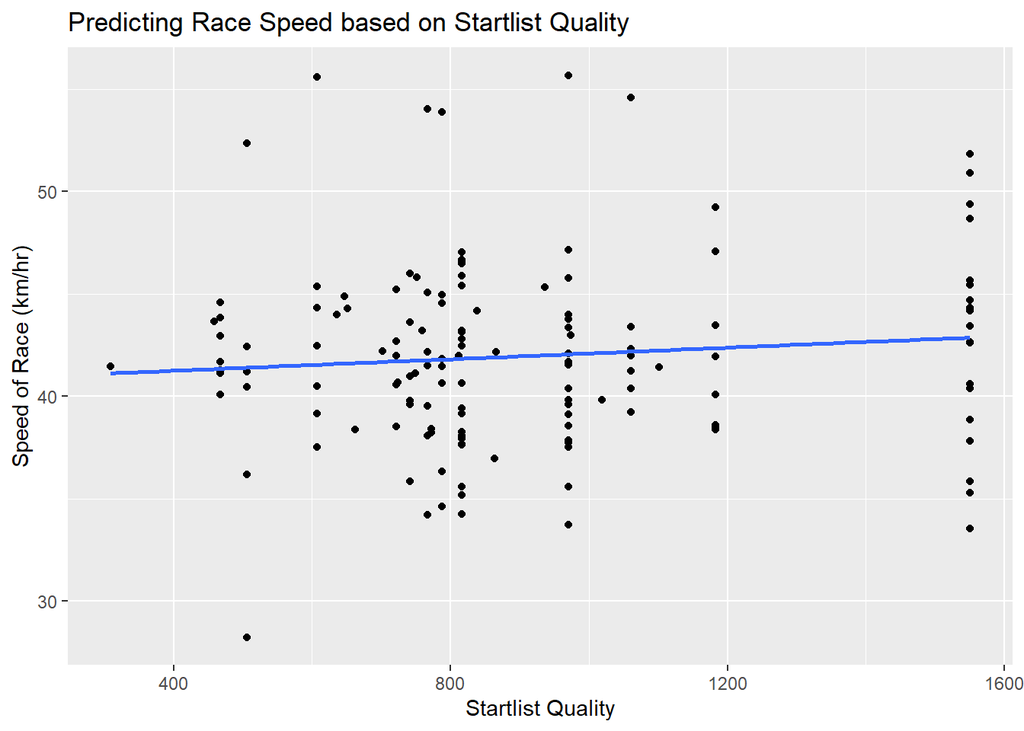

```r
#Race speed versus Startlist quality
ggplot(raceProfile, aes(x=StartlistQualScore, y=AvgSpeedWinner)) +
  geom_point() +
  geom_smooth(method=lm, se=FALSE) +
  labs(title="Predicting Race Speed based on Startlist Quality", x="Startlist Quality", y="Speed of Race (km/hr)")
```

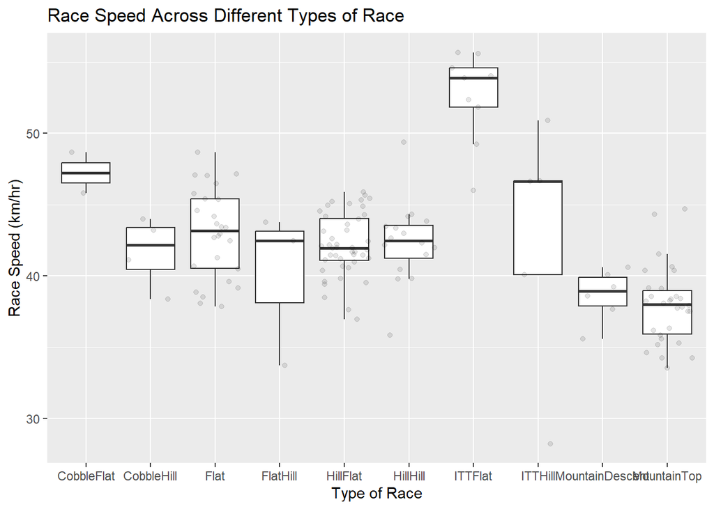

```r
ggplot(raceProfile, aes(x=factor(ParcourTypeCategorical), y=AvgSpeedWinner)) +
  geom_boxplot(outlier.shape=NA) +
  geom_jitter(alpha=0.1) +
  labs(title="Race Speed Across Different Types of Race", x="Type of Race", y="Race Speed (km/hr)")
```

For the scatterplot, there is a weak positive association. I would hesitate to conclude that startlist quality increases the speed of races. There may be some association with speed and startlist quality but it is a weak association.

For the boxplot, race speed varies a lot by the type of race. Note that for most race names, the first word indicates the general profile of the race while the second word indicates how the race finished (ie HillFlat would be a hilly race that ended flat while FlatHill would be a flat race that ended with a hill).

### Correlation

Let’s test out correlation in our dataset.

```r
#test correlation
cor_results <- biking %>%
  select(-Rnk) %>%
  correlate()
```

```
## Non-numeric variables removed from input: `raceName`, `RiderName`, `RiderLastName`, `Team`, `ParcourTypeCategorical`, and `WonByCategorical`
## Correlation computed with
## • Method: 'pearson'
## • Missing treated using: 'pairwise.complete.obs'
```

[figure not shown]

```r
cor_results %>%
  stretch() %>%
  ggplot(aes(x,y,fill=r)) +
  geom_tile() +
  geom_text(aes(label=as.character(fashion(r)))) +
  theme(axis.text.x=element_text(angle=-90))
```

Overall, there are very few variables with super high correlation. A few variables have high correlation as expected. For example, winningTimeHours and winningTimeMin are highly correlated because winningTimeHours was used to calculate winningTimeMin. Also, on PCS race ranking is a function of startlist quality score so it makes sense that RaceRanking and StartlistQualScore have very high correlation. The same is true for VertMeters and ProfileScore. Some other interesting high correlations exist such as between the number of grand tours raced and the age of the rider. It makes sense for there to be a high positive correlation here but for the value to be so high is surprising. Also, winningTimeMin and distance having a correlation of 0.97 is notable. It makes sense that these two are highly correlated but to have a correlation of almost one is notable. It seems like other factors such as vertical meters or even how the riders raced the race would lower the correlation slightly. I am very happy, however, that I have so many variables that have relatively low correlation that I get to play with in my analysis.

### Split data into regression dataset and classification dataset

I am unsure if my data will work better as a regression dataset or as a classification dataset. Thus, I have decided that I am going to try both. In bike races, riders compete heavily for the top 10 but after that riders are not overly worried about whether they finish in 42nd or in 72nd. Thus, for my classification dataset I am going to split the results into a top10 classification and then a notTop10 classification. I will then run models on this classification dataset. The code below is how I created the new classification dataset.

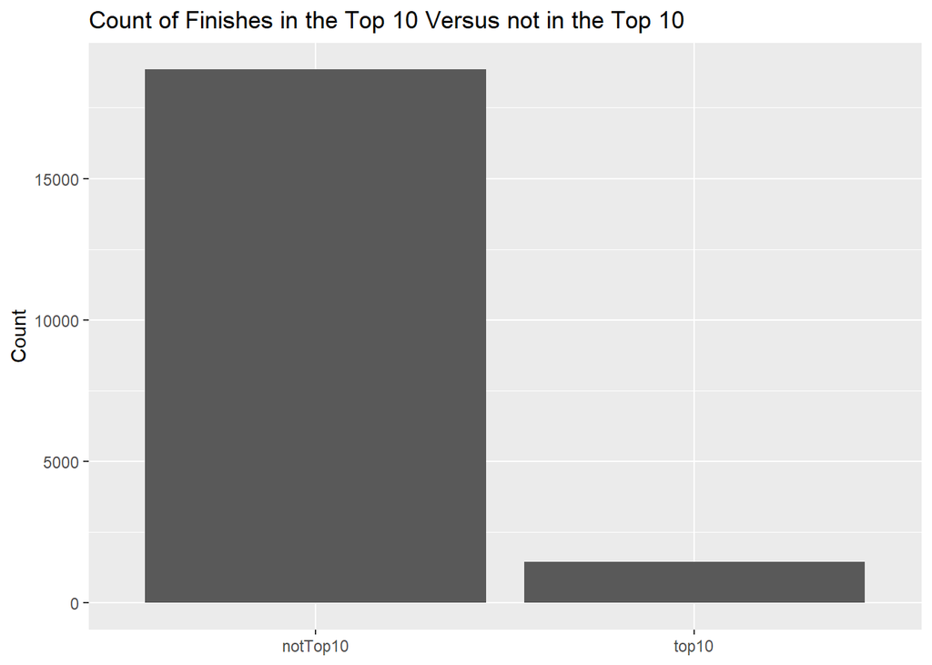

```r
#copy the dataframe
bikingClass <- biking

#assign categories
bikingClass$Rnk <- ifelse(bikingClass$Rnk %in% c(1:10), "top10", "notTop10")

#plot of finishes in top 10 versus not in the top 10
ggplot(bikingClass, aes(x=factor(Rnk))) +
  geom_bar(stat="count") +
  labs(title="Count of Finishes in the Top 10 Versus not in the Top 10", x=NULL, y="Count")
```

```r
#export classification
write_xlsx(bikingClass, here("Project", "rawData", "bikingClass.xlsx"))
```

I will need to conduct some upsampling so that my class sizes are closer to equal. I will upsample to an over_ratio of 0.5